# Lab 2: Linear Regression

Your Name

2024-02-18

Before beginning this lab, you may want to read or skim Section 3.6 in the textbook, or watch [this video*](https://www.youtube.com/watch?v=W0WILgmAGao&list=PL5-da3qGB5IBSSCPANhTgrw82ws7w_or9&index=6). That section includes lots of helpful commands to complete the exercises in this lab. You may also like to check out the file `linear_regression.Rmd` available in the Week 2 module on Canvas.

*Note that the authors use a regular “R Script” rather than a RMarkdown file (which is what this file is). Also, many of their graphics are produced with “base R” rather than the prettier `ggplot` commands we learned in the first lab.

```r
library(tidyverse)
library(openintro)
library(ISLR2)
library(broom)
library(GGally) #ex4
```

This lab will use the `Auto` data set, which is included in the ISLR2 R-package. Use the command `names()` to find the variables of the data set. Try the command `?Auto` to see a full description of the data set and every variable – this command must be used in the console.

```r
names(Auto)
```

```
## [1] "mpg"          "cylinders"    "displacement" "horsepower"   "weight"
## [6] "acceleration" "year"         "origin"       "name"
```

## Simple Linear Regression

### Exercise 1

Use the `lm()` function to perform a simple linear regression with `mpg` as the response and `horsepower` as the predictor. Use the `summary()` and `tidy()` functions to print the results.

For the `tidy()` function, you’ll need to load the `broom` package – best practice is to add it to the other `library()` commands at the top of your RMarkdown document.

```r
ex1 <- lm(mpg ~ horsepower, data = Auto)
summary(ex1)
```

```
##
## Call:
## lm(formula = mpg ~ horsepower, data = Auto)
##
## Residuals:
##      Min       1Q   Median       3Q      Max
## -13.5710  -3.2592  -0.3435   2.7630  16.9240
##
## Coefficients:
##              Estimate Std. Error t value Pr(>|t|)
## (Intercept) 39.935861   0.717499   55.66   <2e-16 ***
## horsepower  -0.157845   0.006446  -24.49   <2e-16 ***
## ---
## Signif. codes:  0 '***' 0.001 '**' 0.01 '*' 0.05 '.' 0.1 ' ' 1
##
## Residual standard error: 4.906 on 390 degrees of freedom
## Multiple R-squared:  0.6059, Adjusted R-squared:  0.6049
## F-statistic: 599.7 on 1 and 390 DF,  p-value: < 2.2e-16
```

```r
print(tidy(ex1))
```

```
## # A tibble: 2 × 5
##   term        estimate std.error statistic   p.value
##   <chr>          <dbl>     <dbl>     <dbl>     <dbl>
## 1 (Intercept)   39.9     0.717        55.7 1.22e-187
## 2 horsepower    -0.158   0.00645     -24.5 7.03e- 81
```

Use your model to answer the following questions:

1. Is there a statistically significant relationship between the predictor and the response? yes there is a significant relationship between horsepower and mpg.
2. How strong is the relationship between the predictor and the response? 60.59%
3. Is the relationship between the predictor and the response positive or negative? it is negative. so we can expect that as the horsepower goes up, the mpg goes down.
4. What is the predicted `mpg` associated with a `horsepower` of 98? What are the associated 95% confidence and prediction intervals?

```r
predict(ex1, newdata = data.frame(horsepower = 98), interval = "confidence")
```

```
##        fit      lwr      upr
## 1 24.46708 23.97308 24.96108
```

```r
predict(ex1, newdata = data.frame(horsepower = 98), interval = "prediction")
```

```
##        fit     lwr      upr
## 1 24.46708 14.8094 34.12476
```

### Exercise 2

Make two plots to visualize your regression model:

1. Plot the response and the predictor using base R. Use the `abline()` function to display the least squares regression line.
2. Use `ggplot` and the `geom_smooth` layer.

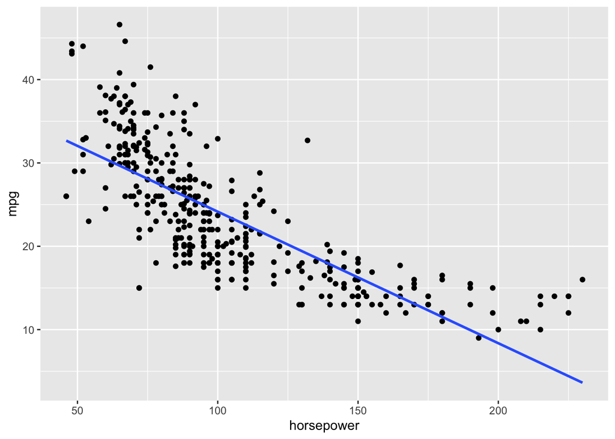

```r
ggplot(Auto, aes(x = horsepower, y = mpg)) +
  geom_point() +
  geom_smooth(method = "lm", se = FALSE)
```

### Exercise 3

You will now evaluate the least squares regression fit of your model. For each of the following “Potential Problems”, compute a measurement statistic, produce a plot, or both. Then comment on whether this might be an issue for your model from above. (You can review these on page 92 of our textbook.)

1. Non-linearity
2. Correlation of error terms
3. Non-constant variance of error terms
4. Not Normal Residuals
5. Outliers
6. High-leverage points
7. Collinearity

## Multiple Linear Regression

### Exercise 4

Produce a scatterplot matrix which includes all of the variables in the data set. Also, compute the matrix of correlations between all of the variables.

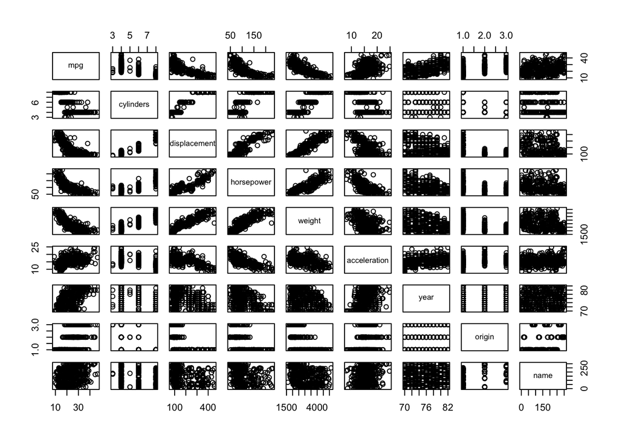

```r
pairs(Auto)
```

```r
#correlation matrix
cor(Auto[ , sapply(Auto, is.numeric)])
```

```
##                     mpg  cylinders displacement horsepower     weight
## mpg           1.0000000 -0.7776175   -0.8051269 -0.7784268 -0.8322442
## cylinders    -0.7776175  1.0000000    0.9508233  0.8429834  0.8975273
## displacement -0.8051269  0.9508233    1.0000000  0.8972570  0.9329944
## horsepower   -0.7784268  0.8429834    0.8972570  1.0000000  0.8645377
## weight       -0.8322442  0.8975273    0.9329944  0.8645377  1.0000000
## acceleration  0.4233285 -0.5046834   -0.5438005 -0.6891955 -0.4168392
## year          0.5805410 -0.3456474   -0.3698552 -0.4163615 -0.3091199
## origin        0.5652088 -0.5689316   -0.6145351 -0.4551715 -0.5850054
##              acceleration       year     origin
## mpg             0.4233285  0.5805410  0.5652088
## cylinders      -0.5046834 -0.3456474 -0.5689316
## displacement   -0.5438005 -0.3698552 -0.6145351
## horsepower     -0.6891955 -0.4163615 -0.4551715
## weight         -0.4168392 -0.3091199 -0.5850054
## acceleration    1.0000000  0.2903161  0.2127458
## year            0.2903161  1.0000000  0.1815277
## origin          0.2127458  0.1815277  1.0000000
```

Now try the command `ggpairs()` instead.

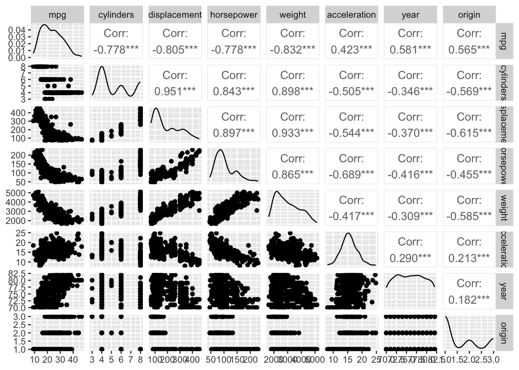

```r
Auto_no_name <- Auto %>% select(-name)
# name was giving me an error because high cardinarlity
ggpairs(Auto_no_name)
```

### Exercise 5

Use the `lm()` function to perform a multiple linear regression with `mpg` as the response and all other variables except `name` as the predictors. Print the results and use them to answer the following:

1. Is there a statistically significant relationship between the predictors and the response as a whole?
2. Which predictors appear to have a statistically significant relationship to the response in this model?
3. What does the coefficient for the `year` variable suggest?

```r
ex5 <- lm(mpg ~ . -name, data = Auto)
summary(ex5)
```

```
##
## Call:
## lm(formula = mpg ~ . - name, data = Auto)
##
## Residuals:
##     Min      1Q  Median      3Q     Max
## -9.5903 -2.1565 -0.1169  1.8690 13.0604
##
## Coefficients:
##                Estimate Std. Error t value Pr(>|t|)
## (Intercept)  -17.218435   4.644294  -3.707  0.00024 ***
## cylinders     -0.493376   0.323282  -1.526  0.12780
## displacement   0.019896   0.007515   2.647  0.00844 **
## horsepower    -0.016951   0.013787  -1.230  0.21963
## weight        -0.006474   0.000652  -9.929  < 2e-16 ***
## acceleration   0.080576   0.098845   0.815  0.41548
## year           0.750773   0.050973  14.729  < 2e-16 ***
## origin         1.426141   0.278136   5.127 4.67e-07 ***
## ---
## Signif. codes:  0 '***' 0.001 '**' 0.01 '*' 0.05 '.' 0.1 ' ' 1
##
## Residual standard error: 3.328 on 384 degrees of freedom
## Multiple R-squared:  0.8215, Adjusted R-squared:  0.8182
## F-statistic: 252.4 on 7 and 384 DF,  p-value: < 2.2e-16
```

### Exercise 6

There is a problem with your multiple linear regression model. Examine the `origin` variable and it’s description (use `?Auto` in the console) to diagnose the problem.

Replace occurences of “origin#” in the code below to create a new variable that accurately encodes the categorical nature of `origin`.

```r
Auto6 <- Auto %>%
  mutate(origin_cat = as.factor(origin))
```

Explore your new variable with the `contrasts()` function, replace your model from Exercise 7 with a new multiple regression model that incorporates your new variable instead of `origin` as a predictor.

### Exercise 7

Repeat the steps in Exercise 3, above to evaluate the least squares regression fit of your model with respect to each of the following “Potential Problems”:

1. Non-linearity
2. Correlation of error terms
3. Non-constant variance of error terms
4. Not Normal Residuals
5. Outliers
6. High-leverage points
7. Collinearity

### Exercise 8

Use the `*` or `:` symbols to fit linear regression models with interaction effects. Do any interactions appear to be statistically significant?

```r
ex8 <- lm(mpg ~ horsepower*weight, data = Auto6)
summary(ex8)
```

```
##
## Call:
## lm(formula = mpg ~ horsepower * weight, data = Auto6)
##
## Residuals:
##      Min       1Q   Median       3Q      Max
## -10.7725  -2.2074  -0.2708   1.9973  14.7314
##
## Coefficients:
##                     Estimate Std. Error t value Pr(>|t|)
## (Intercept)        6.356e+01  2.343e+00  27.127  < 2e-16 ***
## horsepower        -2.508e-01  2.728e-02  -9.195  < 2e-16 ***
## weight            -1.077e-02  7.738e-04 -13.921  < 2e-16 ***
## horsepower:weight  5.355e-05  6.649e-06   8.054 9.93e-15 ***
## ---
## Signif. codes:  0 '***' 0.001 '**' 0.01 '*' 0.05 '.' 0.1 ' ' 1
##
## Residual standard error: 3.93 on 388 degrees of freedom
## Multiple R-squared:  0.7484, Adjusted R-squared:  0.7465
## F-statistic: 384.8 on 3 and 388 DF,  p-value: < 2.2e-16
```

### Exercise 9

Try a few different transformations of variable such as $\log(X), \sqrt{X}, X^2$. Comment on your findings.

```r
ex9_log <- lm(log(mpg) ~ log(horsepower), data = Auto6)
summary(ex9_log)
```

```
##
## Call:
## lm(formula = log(mpg) ~ log(horsepower), data = Auto6)
##
## Residuals:
##      Min       1Q   Median       3Q      Max
## -0.65230 -0.12176  0.00788  0.11631  0.63730
##
## Coefficients:
##                 Estimate Std. Error t value Pr(>|t|)
## (Intercept)      6.96065    0.12149   57.30   <2e-16 ***
## log(horsepower) -0.84185    0.02641  -31.88   <2e-16 ***
## ---
## Signif. codes:  0 '***' 0.001 '**' 0.01 '*' 0.05 '.' 0.1 ' ' 1
##
## Residual standard error: 0.1793 on 390 degrees of freedom
## Multiple R-squared:  0.7227, Adjusted R-squared:  0.722
## F-statistic:  1016 on 1 and 390 DF,  p-value: < 2.2e-16
```

```r
ex9_sqrt <- lm(sqrt(mpg) ~ sqrt(horsepower), data = Auto6)
summary(ex9_sqrt)
```

```
##
## Call:
## lm(formula = sqrt(mpg) ~ sqrt(horsepower), data = Auto6)
##
## Residuals:
##      Min       1Q   Median       3Q      Max
## -1.48861 -0.30666  0.00188  0.28667  1.47256
##
## Coefficients:
##                  Estimate Std. Error t value Pr(>|t|)
## (Intercept)        8.5134     0.1308   65.07   <2e-16 ***
## sqrt(horsepower)  -0.3714     0.0128  -29.02   <2e-16 ***
## ---
## Signif. codes:  0 '***' 0.001 '**' 0.01 '*' 0.05 '.' 0.1 ' ' 1
##
## Residual standard error: 0.4524 on 390 degrees of freedom
## Multiple R-squared:  0.6835, Adjusted R-squared:  0.6826
## F-statistic:   842 on 1 and 390 DF,  p-value: < 2.2e-16
```

```r
ex9_squared <- lm(I(mpg^2) ~ I(horsepower^2), data = Auto6)
summary(ex9_squared)
```

```
##
## Call:
## lm(formula = I(mpg^2) ~ I(horsepower^2), data = Auto6)
##
## Residuals:
##     Min      1Q  Median      3Q     Max
## -571.75 -211.72  -84.04  150.24 1350.03
##
## Coefficients:
##                   Estimate Std. Error t value Pr(>|t|)
## (Intercept)     930.724129  25.174266   36.97   <2e-16 ***
## I(horsepower^2)  -0.025844   0.001593  -16.22   <2e-16 ***
## ---
## Signif. codes:  0 '***' 0.001 '**' 0.01 '*' 0.05 '.' 0.1 ' ' 1
##
## Residual standard error: 309.2 on 390 degrees of freedom
## Multiple R-squared:  0.4028, Adjusted R-squared:  0.4013
## F-statistic: 263.1 on 1 and 390 DF,  p-value: < 2.2e-16
```

### Exercise 10

Write a function that takes a data frame as input, runs a linear regression, and outputs diagnostic plots to help in evaluating the “Potential Problems” of Exercises 3 and 7.

```
##
## Call:
## lm(formula = formula, data = df)
##
## Residuals:
##      Min       1Q   Median       3Q      Max
## -13.5710  -3.2592  -0.3435   2.7630  16.9240
##
## Coefficients:
##              Estimate Std. Error t value Pr(>|t|)
## (Intercept) 39.935861   0.717499   55.66   <2e-16 ***
## horsepower  -0.157845   0.006446  -24.49   <2e-16 ***
## ---
## Signif. codes:  0 '***' 0.001 '**' 0.01 '*' 0.05 '.' 0.1 ' ' 1
##
## Residual standard error: 4.906 on 390 degrees of freedom
## Multiple R-squared:  0.6059, Adjusted R-squared:  0.6049
## F-statistic: 599.7 on 1 and 390 DF,  p-value: < 2.2e-16
```

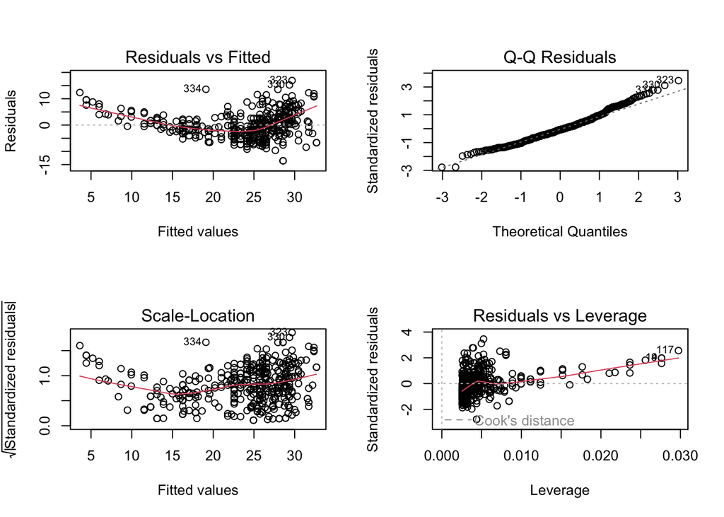

```r
run_regression_diagnostics <- function(df, formula) {
  model <- lm(formula, data = df)
  print(summary(model))
  par(mfrow = c(2, 2))
  plot(model)
}

# Example usage:
run_regression_diagnostics(Auto, mpg ~ horsepower)
```